# Reproducible research assig 1

Matt Henn

March 13, 2015

## Loading/preprocessing data

The first step in this analysis is to download the data and get it in its raw form into R Studio.

```r
setwd("/Users/Matt/RepData_PeerAssessment1")
unzip("activity.zip")
dat <- read.csv("activity.csv")
```

## First bit of analysis

The first deliverables of the assignment are:

- calculate the total number of steps taken per day
- create a histogram of total steps per day
- calculate the mean and median steps taken per day.

However, first we need to get the dates column to be recognized as dates. This is easily accomplished with the lubridate package (install it if you don’t already have it).

```r
library(lubridate)
dat$date <- ymd(dat$date)
class(dat$date)
```

```
## [1] "POSIXct" "POSIXt"
```

Now the total steps taken per day, stored in the data frame tspd.

```r
tspd <- aggregate(steps ~ cut(date, "day"), dat, sum)
```

The histogram of total steps per day.

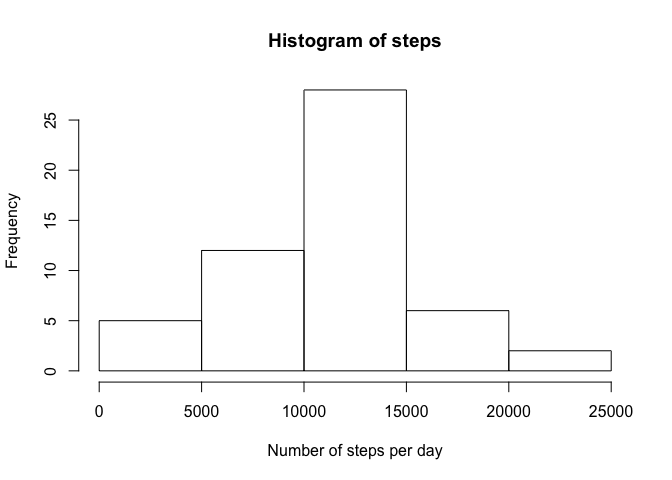

```r
hist(tspd$steps,
     xlab = "Number of steps per day",
     main = "Histogram of steps")
```

Mean and median steps per day.

```r
av <- mean(tspd$steps)
med <- median(tspd$steps)
print(av)
```

```
## [1] 10766.19
```

```r
print(med)
```

```
## [1] 10765
```

## Daily Pattern from data

The next deliverable is to establish some sort of daily pattern, and determine on average, which 5 minute interval has the maximum amount of steps in it.

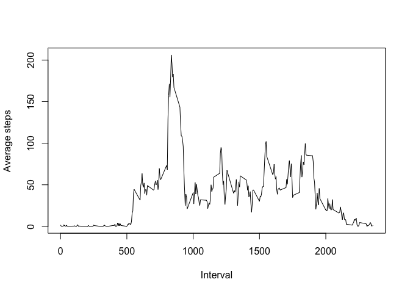

```r
dailyav <- as.data.frame(tapply(dat$steps, dat$interval, mean, na.rm = TRUE))
dailyav$interval <- row.names(dailyav)


plot(dailyav$interval, dailyav[,1],
     type = "l",
     xlab = "Interval",
     ylab = "Average steps")
```

```r
ms <- which.max(dailyav[,1])
maxavsteps <- dailyav[ms,2]
print(maxavsteps)
```

```
## [1] "835"
```

As shown above, the maximum average steps occur at the 0835 interval. Perhaps this is the morning commute.

## Imputing missing values

*Calculate and report the number of missing values in the dataset.*

```r
length(which(is.na(dat$steps)))
```

```
## [1] 2304
```

```r
length(which(is.na(dat$date)))
```

```
## [1] 0
```

```r
length(which(is.na(dat$interval)))
```

```
## [1] 0
```

```r
dat1 <- dat
dat1$steps[is.na(dat1$steps)] <- tapply(dat1$steps, dat1$interval, mean, na.rm = TRUE)
length(which(is.na(dat1$steps)))
```

```
## [1] 0
```

Our goal has been accomplished in dat1. Let’s see if this changed the mean and median total steps taken per day.

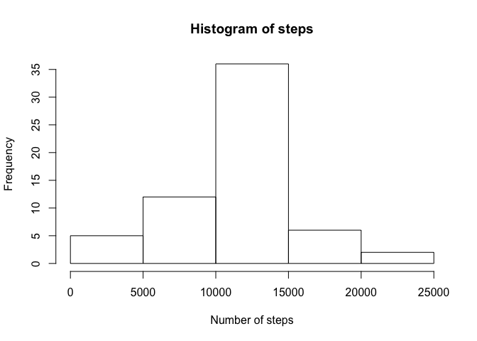

```r
tspd1 <- aggregate(steps ~ cut(date, "day"), dat1, sum)
hist(tspd1$steps,
     xlab = "Number of steps",
     main = "Histogram of steps")
```

```r
av1 <- mean(tspd1$steps)
med1 <- median(tspd1$steps)
print(av1)
```

```
## [1] 10766.19
```

```r
print(med1)
```

```
## [1] 10766.19
```

## Differences between weekdays and weekends

To establish which days in the dataset are weekdays and which are weekends we will use a combination of the weekdays() and ifelse() functions.

```r
dat1$day <- weekdays(dat1$date)
dat1$tday <- ifelse((dat1$day == "Saturday"), dat1$tday <- "weekend",
                    (ifelse((dat1$day == "Sunday"), dat1$tday <- "weekend", dat1$tday <- "weekday")))
```

The next step is to figure out how the average number of steps varies from weekdays to weekends, and display the comparison in 2 time-series plots.

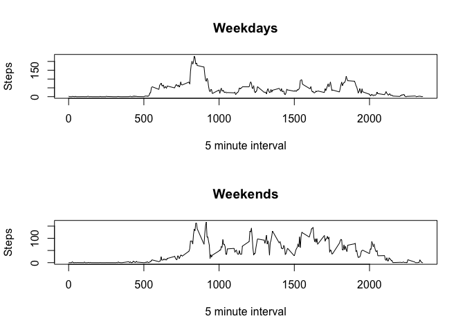

```r
dat2 <- subset(dat1, dat1$tday == "weekday")
weekdayav <- as.data.frame(tapply(dat2$steps, dat2$interval, mean, na.rm = TRUE))

dat3 <- subset(dat1, dat1$tday == "weekend")
weekendav <- as.data.frame(tapply(dat3$steps, dat3$interval, mean, na.rm = TRUE))

par(mfrow = c(2,1))
plot(row.names(weekdayav), weekdayav[,1],
     type = "l",
     ylab = "Steps",
     xlab = "5 minute interval",
     main = "Weekdays")
plot(row.names(weekendav), weekendav[,1],
     type = "l",
     ylab = "Steps",
     xlab = "5 minute interval",
     main = "Weekends")
```

Looks like there is a difference between the two day types - indicating this person works a regular Monday to Friday job, and is more active on the weekends.